# Mini-Project: COVID-19 Vaccination Rates

Divya Shetty (A15390408)

3/3/2022

## Getting Started

Import and examine the vaccination data.

```r
vax <- read.csv("covid19vaccinesbyzipcode_test.csv")
head(vax)
```

```
##   as_of_date zip_code_tabulation_area local_health_jurisdiction         county
## 1 2021-01-05                    92549                 Riverside      Riverside
## 2 2021-01-05                    92130                 San Diego      San Diego
## 3 2021-01-05                    92397            San Bernardino San Bernardino
## 4 2021-01-05                    94563              Contra Costa   Contra Costa
## 5 2021-01-05                    94519              Contra Costa   Contra Costa
## 6 2021-01-05                    91042               Los Angeles    Los Angeles
##   vaccine_equity_metric_quartile                 vem_source
## 1                              3 Healthy Places Index Score
## 2                              4 Healthy Places Index Score
## 3                              3 Healthy Places Index Score
## 4                              4 Healthy Places Index Score
## 5                              3 Healthy Places Index Score
## 6                              2 Healthy Places Index Score
##   age12_plus_population age5_plus_population persons_fully_vaccinated
```

[output cut: 34 more lines]

**Q1. What column details the total number of people fully vaccinated?**

The column is called “persons_fully_vaccinated”.

**Q2. What column details the Zip code tabulation area?**

The column is “zip_code_tabulation_area”.

**Q3. What is the earliest date in this dataset?**

```r
vax$as_of_date[1]
```

```
## [1] "2021-01-05"
```

The earliest date is “2021-01-05”.

**Q4. What is the latest date in this dataset?**

```r
vax$as_of_date[length(vax$as_of_date)]
```

```
## [1] "2022-03-01"
```

The latest date is “2022-03-01”.

Use the skim() function to get an overview of the data.

```r
skimr::skim(vax)
```

Data summary

| Name | vax |
| --- | --- |
| Number of rows | 107604 |
| Number of columns | 15 |
| _______________________ |  |
| Column type frequency: |  |
| character | 5 |
| numeric | 10 |
| ________________________ |  |
| Group variables | None |

**Variable type: character**

| skim_variable | n_missing | complete_rate | min | max | empty | n_unique | whitespace |
| --- | --- | --- | --- | --- | --- | --- | --- |
| as_of_date | 0 | 1 | 10 | 10 | 0 | 61 | 0 |
| local_health_jurisdiction | 0 | 1 | 0 | 15 | 305 | 62 | 0 |
| county | 0 | 1 | 0 | 15 | 305 | 59 | 0 |
| vem_source | 0 | 1 | 15 | 26 | 0 | 3 | 0 |
| redacted | 0 | 1 | 2 | 69 | 0 | 2 | 0 |

**Variable type: numeric**

| skim_variable | n_missing | complete_rate | mean | sd | p0 | p25 | p50 | p75 | p100 | hist |
| --- | --- | --- | --- | --- | --- | --- | --- | --- | --- | --- |
| zip_code_tabulation_area | 0 | 1.00 | 93665.11 | 1817.39 | 90001 | 92257.75 | 93658.50 | 95380.50 | 97635.0 | ▃▅▅▇▁ |
| vaccine_equity_metric_quartile | 5307 | 0.95 | 2.44 | 1.11 | 1 | 1.00 | 2.00 | 3.00 | 4.0 | ▇▇▁▇▇ |
| age12_plus_population | 0 | 1.00 | 18895.04 | 18993.91 | 0 | 1346.95 | 13685.10 | 31756.12 | 88556.7 | ▇▃▂▁▁ |
| age5_plus_population | 0 | 1.00 | 20875.24 | 21106.02 | 0 | 1460.50 | 15364.00 | 34877.00 | 101902.0 | ▇▃▂▁▁ |
| persons_fully_vaccinated | 18338 | 0.83 | 12155.61 | 13063.88 | 11 | 1066.25 | 7374.50 | 20005.00 | 77744.0 | ▇▃▁▁▁ |
| persons_partially_vaccinated | 18338 | 0.83 | 831.74 | 1348.68 | 11 | 76.00 | 372.00 | 1076.00 | 34219.0 | ▇▁▁▁▁ |
| percent_of_population_fully_vaccinated | 18338 | 0.83 | 0.51 | 0.26 | 0 | 0.33 | 0.54 | 0.70 | 1.0 | ▅▅▇▇▃ |
| percent_of_population_partially_vaccinated | 18338 | 0.83 | 0.05 | 0.09 | 0 | 0.01 | 0.03 | 0.05 | 1.0 | ▇▁▁▁▁ |
| percent_of_population_with_1_plus_dose | 18338 | 0.83 | 0.54 | 0.28 | 0 | 0.36 | 0.58 | 0.75 | 1.0 | ▅▃▆▇▅ |
| booster_recip_count | 64317 | 0.40 | 4100.55 | 5900.21 | 11 | 176.00 | 1136.00 | 6154.50 | 50602.0 | ▇▁▁▁▁ |

**Q5. How many numeric columns are in this dataset?**

There are 10 numeric columns.

**Q6. Note that there are “missing values” in the dataset. How many NA values there in the persons_fully_vaccinated column?**

```r
sum(is.na(vax$persons_fully_vaccinated))
```

```
## [1] 18338
```

There are 18338 NA values for “persons_fully_vaccinated”.

**Q7. What percent of persons_fully_vaccinated values are missing (to 2 significant figures)?**

```r
sum(is.na(vax$persons_fully_vaccinated)) / length(vax$persons_fully_vaccinated)
```

```
## [1] 0.1704212
```

About 17.04% of the values in “persons_fully_vaccinated” are missing.

**Q8. [Optional]: Why might this data be missing?**

Missing values may be due to no records being collected from a given county.

## Working with Dates

The lubridate package let’s us use date data in a useful manner. Convert dates into lubridate formate and perform math operations with it!

```r
library(lubridate)
today()
```

```
## [1] "2022-03-07"
```

```r
#specify the year-month-day format when converting
vax$as_of_date <- ymd(vax$as_of_date)
```

```r
#how many days have passed since the first vaccination?
today() - vax$as_of_date[1]
```

```
## Time difference of 426 days
```

```r
#how many days does the dataset span?
vax$as_of_date[nrow(vax)] - vax$as_of_date[1]
```

```
## Time difference of 420 days
```

**Q9. How many days have passed since the last update of the dataset?**

```r
today() - vax$as_of_date[nrow(vax)]
```

```
## Time difference of 6 days
```

**Q10. How many unique dates are in the dataset (i.e. how many different dates are detailed)?**

```r
length(unique(vax$as_of_date))
```

```
## [1] 61
```

There are 61 different dates in the dataset.

## Working with ZIP Codes

In R, we can use the zipcodeR package to make working with ZIP codes - a postal code used by the United States Postal Service (USPS) - easier.

```r
library(zipcodeR)

#calculate the distance between the centroids of two zip codes in miles
zip_distance('92037','92109')
```

```
##   zipcode_a zipcode_b distance
## 1     92037     92109     2.33
```

```r
#pull census data for zip code areas
reverse_zipcode(c('92037', "92109") )
```

```
## # A tibble: 2 x 24
##   zipcode zipcode_type major_city post_office_city common_city_list county state
##   <chr>   <chr>        <chr>      <chr>                      <blob> <chr>  <chr>
## 1 92037   Standard     La Jolla   La Jolla, CA           <raw 20 B> San D~ CA
## 2 92109   Standard     San Diego  San Diego, CA          <raw 21 B> San D~ CA
## # ... with 17 more variables: lat <dbl>, lng <dbl>, timezone <chr>,
## #   radius_in_miles <dbl>, area_code_list <blob>, population <int>,
## #   population_density <dbl>, land_area_in_sqmi <dbl>,
## #   water_area_in_sqmi <dbl>, housing_units <int>,
## #   occupied_housing_units <int>, median_home_value <int>,
## #   median_household_income <int>, bounds_west <dbl>, bounds_east <dbl>,
## #   bounds_north <dbl>, bounds_south <dbl>
```

## Focus on the San Diego Area

Use the dplyr package to restrict the data to only the San Diego area.

```r
library(dplyr)

sd <- filter(vax, county == "San Diego")
nrow(sd)
```

```
## [1] 6527
```

The dplyr package can also be useful when trying to subset with multiple criteria. For example:

```r
sd.10 <- filter(vax, county == "San Diego" & age5_plus_population > 10000)
```

**Q11. How many distinct zip codes are listed for San Diego County?**

```r
length(unique(sd$zip_code_tabulation_area))
```

```
## [1] 107
```

There are 107 unique zip codes for the San Diego County.

**Q12. What San Diego County Zip code area has the largest 12 + Population in this dataset?**

```r
sd$zip_code_tabulation_area[which.max(sd$age12_plus_population)]
```

```
## [1] 92154
```

The ‘92154’ zip code area has the largest 12+ population.

Select all San Diego “county” entries on “as_of_date” “2022-02-22” and use this for the following questions.

```r
sd.feb <- filter(vax, county == "San Diego" & as_of_date == "2022-02-22")
```

**Q13. What is the overall average “Percent of Population Fully Vaccinated” value for all San Diego “County” as of “2022-02-22”?**

```r
mean(sd.feb$percent_of_population_fully_vaccinated, na.rm = TRUE)
```

```
## [1] 0.7041551
```

The average percent of population fully vaccinated in the San Diego County as of 2022-02-22 is 70.42%.

**Q14. Using either ggplot or base R graphics make a summary figure that shows the distribution of Percent of Population Fully Vaccinated values as of “2022-02-22”?**

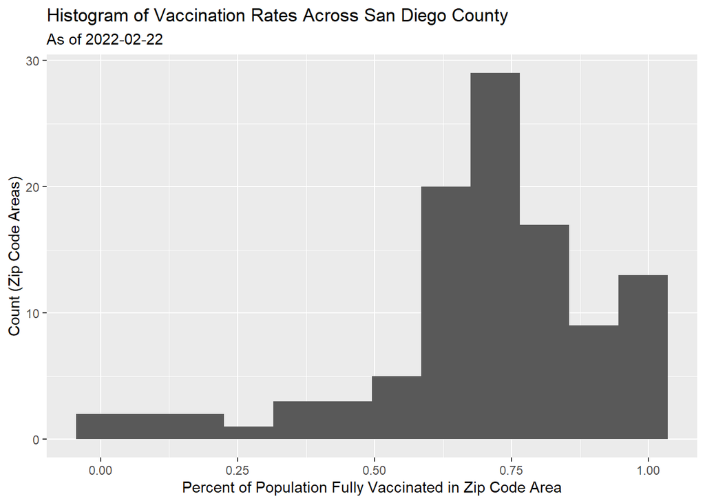

```r
library(ggplot2)

ggplot(sd.feb) +
  aes(x = percent_of_population_fully_vaccinated) +
  geom_histogram(bins = 12) +
  labs(title = "Histogram of Vaccination Rates Across San Diego County",
       subtitle = "As of 2022-02-22",
       x = "Percent of Population Fully Vaccinated in Zip Code Area",
       y = "Count (Zip Code Areas)")
```

## Focus on UCSD/La Jolla

UC San Diego resides in the 92037 ZIP code area and is listed with an age 5+ population size of 36,144. Use this information to subset the data and check that it’s done correctly.

```r
ucsd <- filter(sd, zip_code_tabulation_area == "92037")
ucsd[1,]$age5_plus_population
```

```
## [1] 36144
```

**Q15. Using ggplot make a graph of the vaccination rate time course for the 92037 ZIP code area.**

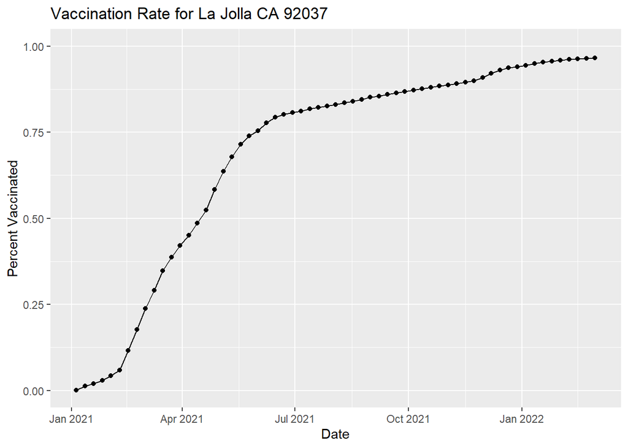

```r
ggplot(ucsd) +
  aes(x = as_of_date, y = percent_of_population_fully_vaccinated) +
  geom_point() +
  geom_line(group = 1) +
  ylim(c(0, 1)) +
  labs(title = "Vaccination Rate for La Jolla CA 92037",
       x = "Date", y = "Percent Vaccinated")
```

## Comparing to Similar Size Areas

Look across every zip code area with a population at least as large as that of 92037 on as_of_date “2022-02-22”.

```r
vax.36 <- filter(vax, age5_plus_population > 36144 & as_of_date == "2022-02-22")

head(vax.36)
```

```
##   as_of_date zip_code_tabulation_area local_health_jurisdiction      county
## 1 2022-02-22                    92840                    Orange      Orange
## 2 2022-02-22                    92064                 San Diego   San Diego
## 3 2022-02-22                    92508                 Riverside   Riverside
## 4 2022-02-22                    95403                    Sonoma      Sonoma
## 5 2022-02-22                    90001               Los Angeles Los Angeles
## 6 2022-02-22                    92802                    Orange      Orange
##   vaccine_equity_metric_quartile                 vem_source
## 1                              2 Healthy Places Index Score
## 2                              4 Healthy Places Index Score
## 3                              3 Healthy Places Index Score
## 4                              3 Healthy Places Index Score
## 5                              1 Healthy Places Index Score
## 6                              2 Healthy Places Index Score
##   age12_plus_population age5_plus_population persons_fully_vaccinated
```

[output cut: 27 more lines]

**Q16. Calculate the mean “Percent of Population Fully Vaccinated” for ZIP code areas with a population as large as 92037 (La Jolla) as_of_date “2022-02-22”. Add this as a straight horizontal line to your plot from above with the geom_hline() function?**

```r
avg.per <- mean(vax.36$percent_of_population_fully_vaccinated, na.rm = TRUE)
avg.per
```

```
## [1] 0.733385
```

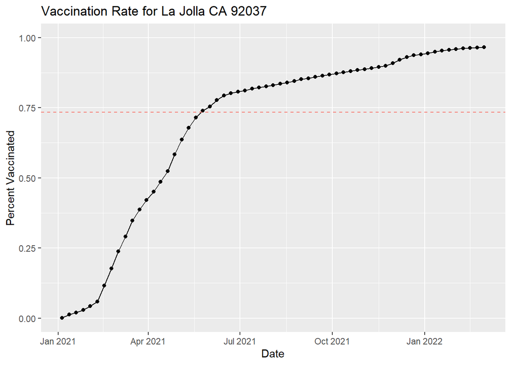

```r
ggplot(ucsd) +
  aes(x = as_of_date, y = percent_of_population_fully_vaccinated) +
  geom_point() +
  geom_line(group = 1) +
  ylim(c(0, 1)) +
  labs(title = "Vaccination Rate for La Jolla CA 92037",
       x = "Date", y = "Percent Vaccinated") +
  geom_hline(aes(yintercept = avg.per, color = "red"),
             linetype = "dashed", show.legend = FALSE)
```

**Q17. What is the 6 number summary (Min, 1st Qu., Median, Mean, 3rd Qu., and Max) of the “Percent of Population Fully Vaccinated” values for ZIP code areas with a population as large as 92037 (La Jolla) as_of_date “2022-02-22”?**

```r
summary(vax.36$percent_of_population_fully_vaccinated)
```

```
##    Min. 1st Qu.  Median    Mean 3rd Qu.    Max.
##  0.3881  0.6539  0.7333  0.7334  0.8027  1.0000
```

**Q18. Using ggplot generate a histogram of this data.**

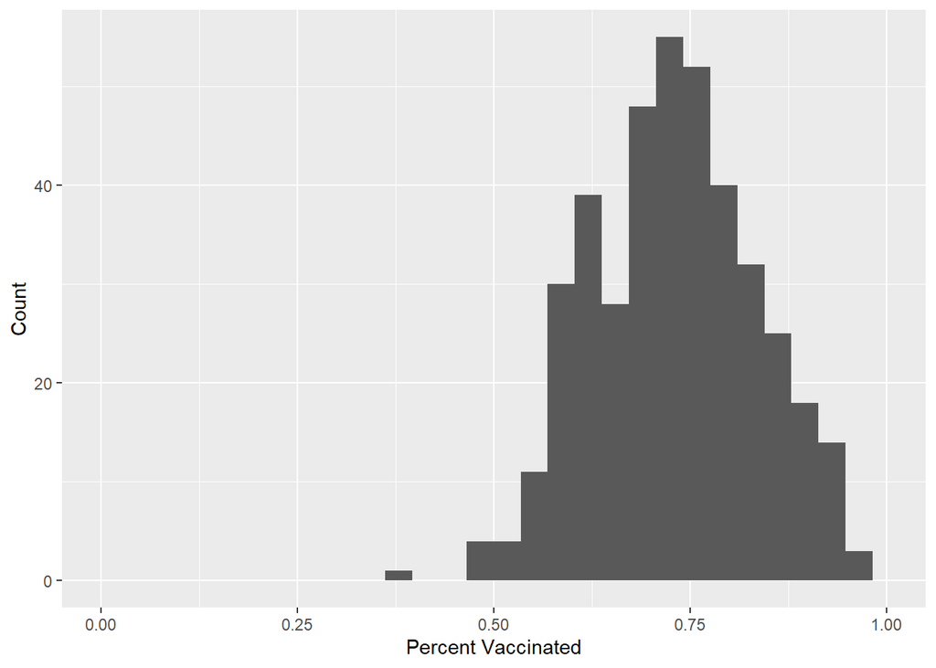

```r
ggplot(vax.36) +
  aes(x = percent_of_population_fully_vaccinated) +
  geom_histogram(bins = 30) +
  labs(x = "Percent Vaccinated", y = "Count") +
  xlim(c(0, 1))
```

**Q19. Is the 92109 and 92040 ZIP code areas above or below the average value you calculated for all these above?**

```r
#92109
vax %>% filter(as_of_date == "2022-02-22") %>%
  filter(zip_code_tabulation_area=="92109") %>%
  select(percent_of_population_fully_vaccinated)
```

```
##   percent_of_population_fully_vaccinated
## 1                               0.723044
```

```r
#92040
vax %>% filter(as_of_date == "2022-02-22") %>%
  filter(zip_code_tabulation_area == "92040") %>%
  select(percent_of_population_fully_vaccinated)
```

```
##   percent_of_population_fully_vaccinated
## 1                               0.551304
```

Both zip code areas are below the average value calculated.

**Q20. Finally make a time course plot of vaccination progress for all areas in the full dataset with age5_plus_population > 36144.**

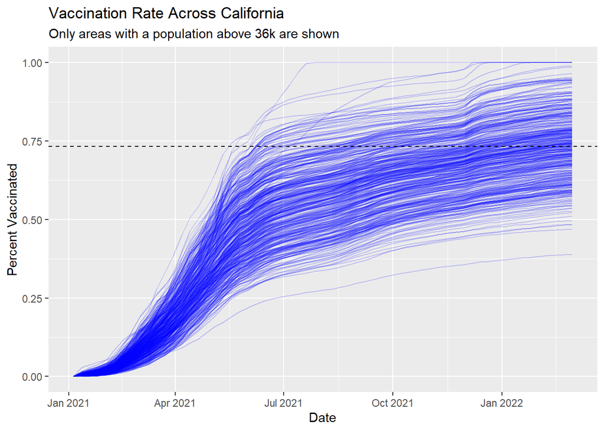

```r
vax.36.all <- filter(vax, age5_plus_population > 36144)


ggplot(vax.36.all) +
  aes(x = as_of_date,
      y = percent_of_population_fully_vaccinated,
      group = zip_code_tabulation_area) +
  geom_line(alpha = 0.2, color = "blue") +
  ylim(c(0, 1)) +
  labs(x = "Date", y = "Percent Vaccinated",
       title = "Vaccination Rate Across California",
       subtitle = "Only areas with a population above 36k are shown") +
  geom_hline(yintercept = avg.per, linetype = "dashed")
```

**Q21. How do you feel about traveling for Spring Break and meeting for in-person class afterwards?**

I would not feel comfortable traveling for break considering that nearly half of the largely populated areas don’t have a great majority of their population vaccinated. This would make having in-person classes after break riskier since we can’t guarantee that each location everyone traveled to was safe.